# Ethics in Negotiation

Session 1

Luis F. Gómez L.

luis.gomezl@unimilitar.edu.co

Distance Learning Faculty

8 September, 2026

# Please Read Me

- Check the message **Welcome greeting** published in the News Bulletin Board.
- Dear student please edit your profile uploading a photo where your face is clearly visible.
- The purpose of the virtual meetings is to answer questions and not to make a summary of the study material.
- This presentation is based on (Lewicki et al., 2024, Chapter 5)
- **Purpose**
  - Explore and understand widely accepted ethical standards in negotiation to identify, evaluate, and respond to deceptive tactics effectively.

# Ethics and its relationship with negotiation

- Ethics is understand as the social standards that are apply to examine what is right or wrong in a specific situation or a process to establish such standards (Lewicki et al., 2024, Chapter 5, p. 136).
- The ethical considerations in a negotiation are related to how the exchange of information occurs (Lewicki & Robinson, 1998).
  - Because the exchange of information in the negotiation process is vital, the analysis of ethics is associated with examining whether or not there is a dishonest communication.
- To evaluate how ethical the strategies and tactics are in a negotiation, 4 standards can be used (Lewicki et al., 2024, Chapter 5, p. 118):

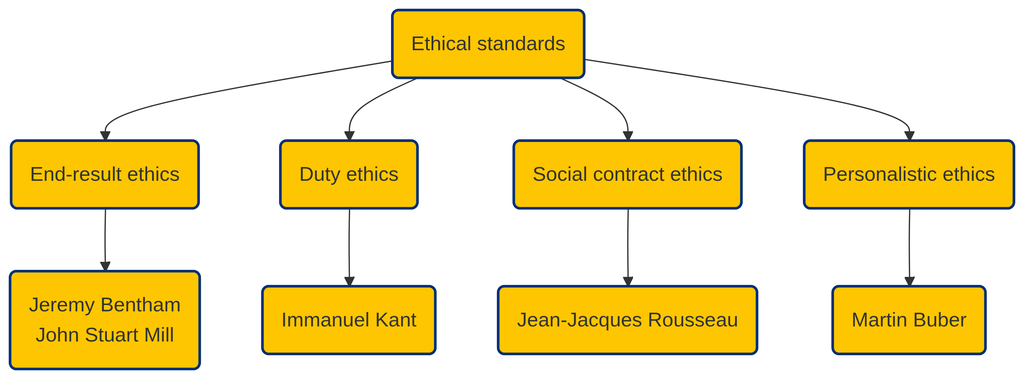

Figure 1: Approaches to ethical reasoning to evaluate strategies and tactics in a negotiation (Lewicki et al., 2024, p. 140)

# Ethically ambiguous tactics

- There are tactics that are not ethical and that can be quickly identified, such as stealing confidential data from the counterpart.
  - These types of tactics must be removed from the negotiator’s toolbox.
- However, in the context of negotiation there are gray areas. These gray areas are known as ethically ambiguous tactics within the theory of negotiation.
  - These tactics are related to what the negotiators say or what they claim they will do concerning what they really do.
- Gray areas within a negotiating context regarding ethically ambiguous tactics are presented due to the 2 dilemmas a negotiator faces:
  - Dilemma of honesty
    - How much truth should be revealed to the counterpart?
  - Dilemma of trust
    - How much should a negotiator believe what the counterpart says?

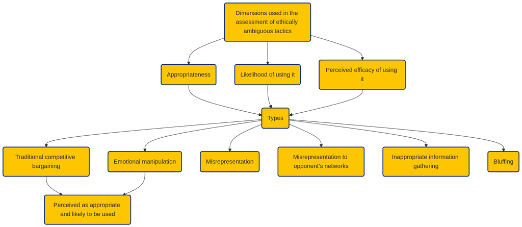

Figure 2: Types of ethically ambiguous tactics (Lewicki et al., 2024, p. 148)

# Motives and consequences of using deceptive tactics

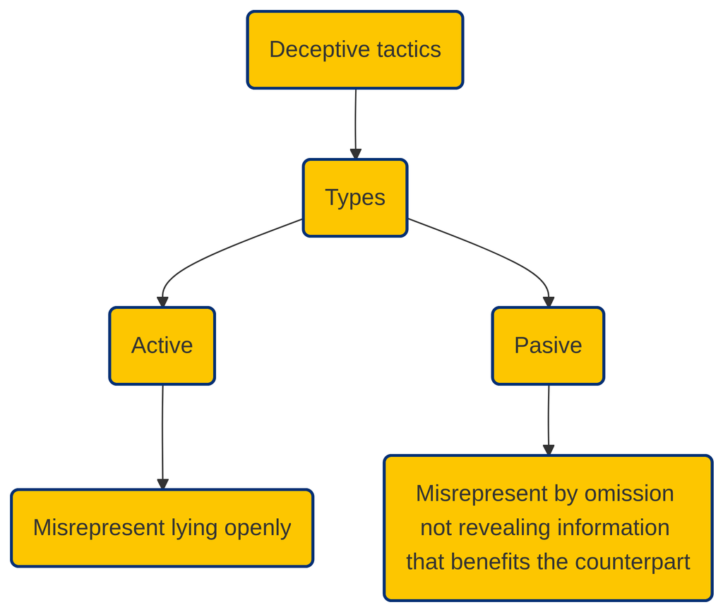

Figure 3: Use of deceptive tactics (Lewicki et al., 2024, p. 151)

- Why do negotiators use deceptive tactics in the context of a negotiation?
  - Need to acquire greater power through the manipulation of information to get closer to the target point
  - Use of a more competitive negotiation style[^1]

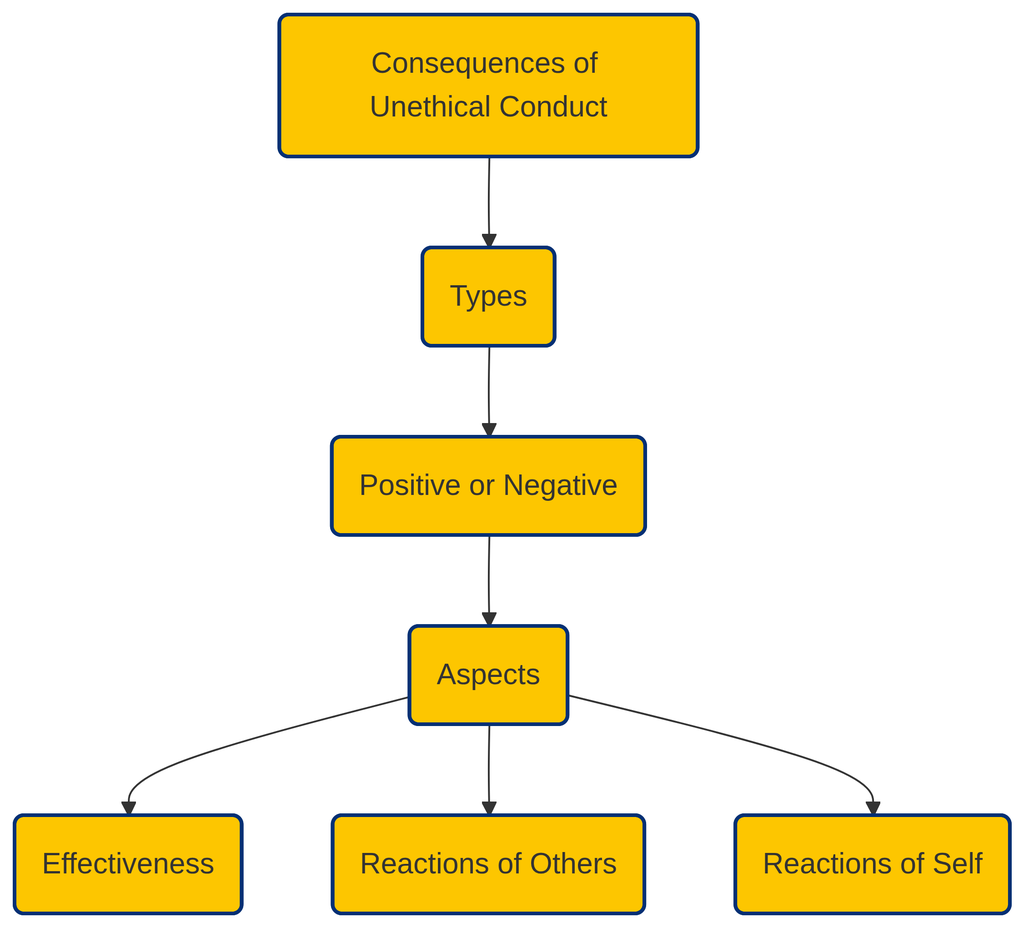

Figure 4: Consequences of unethical conduct (Lewicki et al., 2024, pp. 155–158)

- **Effectiveness**
  - Deceptive tactics generate **positive consequences** when the outcome of the negotiation improves compared to whether a negotiator had acted ethically and if the conduct is not punished where the consequences materialize in the short run.
  - Deceptive tactics generate **negative consequences** because the reputation of the negotiator is damaged where the consequences materialize in the future.
- **Reactions of Others**
  - Deceptive tactics generate **positive consequences** only if constituents, indirect actors or interest observers considered appropriate to use this type of tactics[^2].
  - Deceptive tactics generate **negative consequences** because retaliations occur directly from the counterpart and possibly from the constituents, indirect actors or interest observers if they consider that the tactic used is inappropriate[^3].
- **Reactions of Self**
  - Deceptive tactics generate **positive consequences** only if the negotiator does not suffer from guilt, remorse or discomfort.
  - Deceptive tactics generate **negative consequences** when the negotiator suffers from guilt, remorse or discomfort for having used these tactics[^4]

# Dealing with the use of deceptive tactics by the counterpart

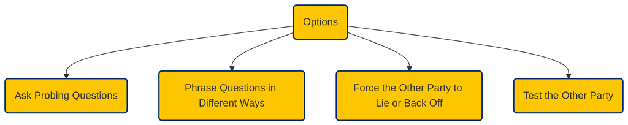

Figure 5: Dealing with deceptive tactics by the counterpart (Lewicki et al., 2024, pp. 172–174)

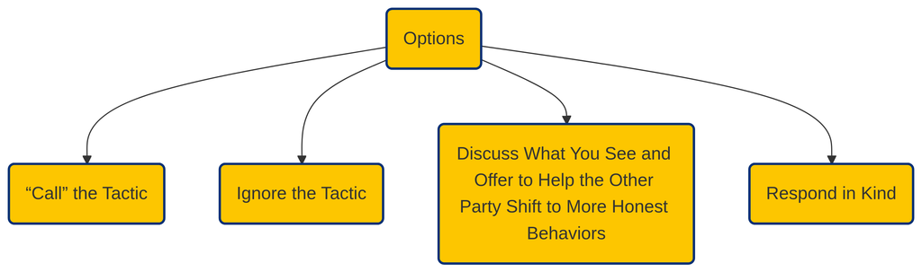

Figure 6: Dealing with deceptive tactics by the counterpart (Lewicki et al., 2024, pp. 172–174)

- **My personal opinion**:
  - Read the article (Adler, 2007):
    - Before the Bargaining Begins
    - During the Bargaining Process
  - I think the best approach is to follow the recommendations in the section **Before the Bargaining Begins** because they are carried out during the planning stage of a negotiation where there is more time and information that can be collected in order to respond adequately to deceptive tactics.

# Acknowledgments

- To my family that supports me
- To the taxpayers of Colombia and the [**UMNG students**](https://www.umng.edu.co/estudiante) who pay my salary
- To the [**Business Science**](https://www.business-science.io/) and [**R4DS Online Learning**](https://www.rfordatasci.com/) communities where I learn [**R**](https://www.r-project.org/about.html) and [**$\pi$-thon**](https://www.python.org/about/)
- To the [**R Core Team**](https://www.r-project.org/contributors.html), the creators of [**RStudio IDE**](https://rstudio.com/products/rstudio/), [**Quarto**](https://quarto.org/) and the authors and maintainers of the packages [**tinytex**](https://CRAN.R-project.org/package=tinytex) for allowing me to access these tools without paying for a license

# References

Adler, R. S. (2007). Negotiating with liars. *MIT Sloan Management Review*, *48*(4), 69–79.

Lewicki, R. J., Barry, B., & Saunders, D. M. (2024). *Negociación* (9th ed.). McGraw-Hill Education. https://www-ebooks7-24-com.ezproxy.umng.edu.co/?il=40562

Lewicki, R. J., & Robinson, R. J. (1998). Ethical and Unethical Bargaining Tactics: An Empirical Study. *Journal of Business Ethics*, *18*(2), 211–228. https://doi.org/10.1023/A:1005719122519

## Footnotes

[^1]: This aspect generates a greater probability of using this type of tactics
[^2]: This is my own personal opinion and it is not mentioned in (Lewicki et al., 2024, Chapter 5)
[^3]: As a personal opinion in the case of the indirect actors or interest observers the retaliation is materialize through a social sanction.
[^4]: This issue directly affects the negotiation since the negotiator is willing to make greater concessions to the counterpart to compensate for using deceptive tactics.